# Homework 4

Zoheb Allam

October 24, 2016

This is the code for Homework Assignemnt 4. This bootstrap code illustrates the central limit theorem using a normal distribution and an exponential distribution.

The central limit theorem states that if you treat your small sample as a population and take the mean of values from that population x number of time, the sample mean will be approximately normally distributed. This is only true for large sample sizes.

```r
n1 <- 6
nsim <- 1000
bootmean1 <- numeric (nsim)
for (i in 1:nsim) {
  x1 <- rnorm(n1)
  bootmean1 [i] <- mean (x1)
}
```

The two histograms below indicate the distribution of the original variable with 6 observations. As you can its highly nonnormal, but the histogram of the bootstrapped mean is normally distributed.

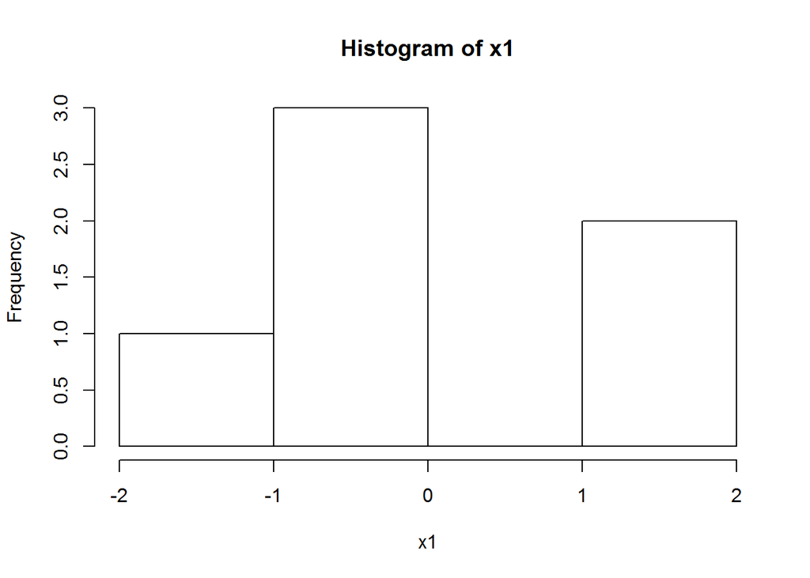

```r
hist(x1)
```

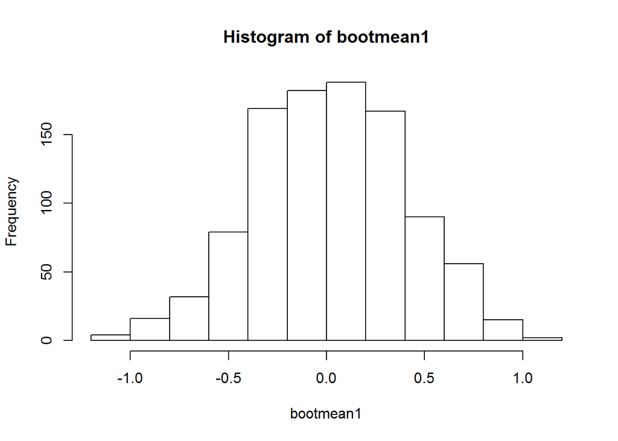

```r
hist (bootmean1)
```

This code is for an n of 70 once again with a normal distribution. R has generated 70 normal random values.

```r
n2 <- 70
nsim <- 1000
bootmean2 <- numeric (nsim)
for (i in 1:nsim) {
  x2 <- rnorm(n2)
  bootmean2 [i] <- mean (x2)
}
```

The two histograms below indicate the difference in the distribution. The original variable looks better than with an n of 6 but its still not quite normal. The bootstrapped mean is however.

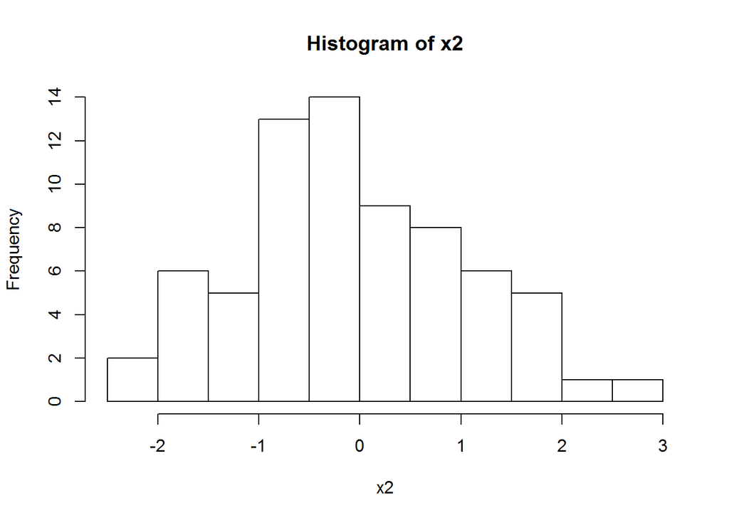

```r
hist(x2)
```

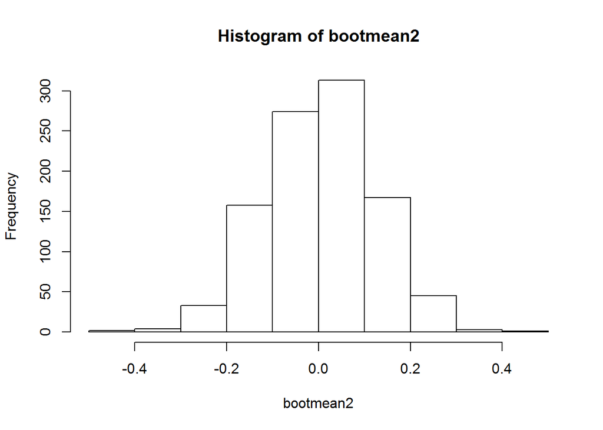

```r
hist (bootmean2)
```

```r
n3 <- 12
nsim <- 1000
bootmean3 <- numeric (nsim)
for (i in 1:nsim) {
  x3 <- rexp(n3)
  bootmean3 [i] <- mean (x3)
}
```

These two graphs indicates that the central limit theorem still applies even for an exponential distribution. The bootstrapped variable is now relatively normal.

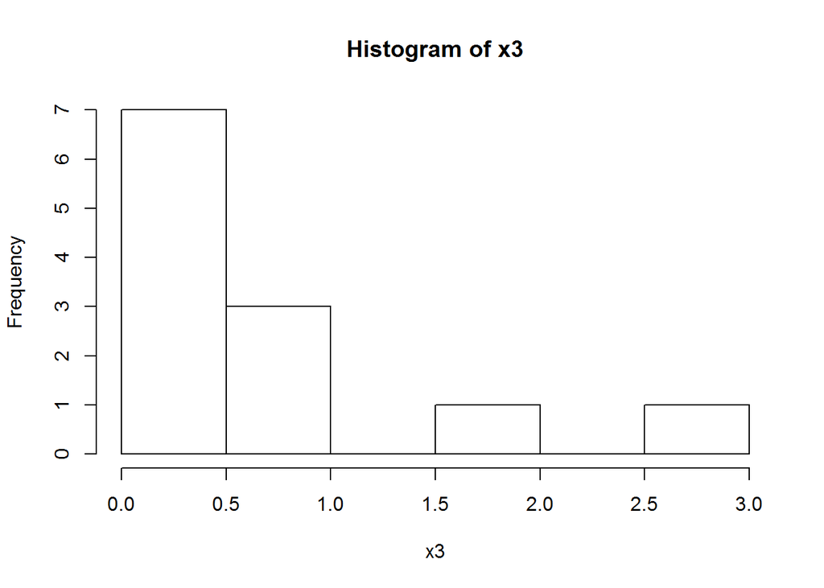

```r
hist(x3)
```

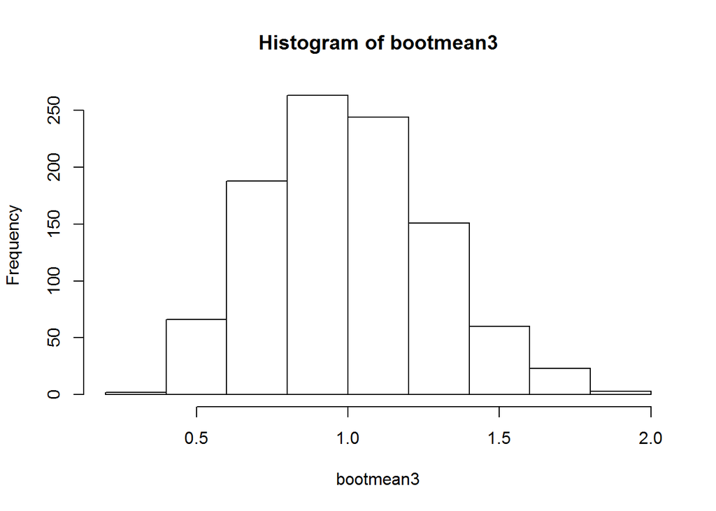

```r
hist (bootmean3)
```

This final code uses the same exponential distribution but a larger n.

```r
n4 <- 80
nsim <- 1000
bootmean4 <- numeric (nsim)
for (i in 1:nsim) {
  x4 <- rexp(n4)
  bootmean4 [i] <- mean (x4)
}
```

The histogram for the original variable is heavily skewed but the bootmean is normally distributed.

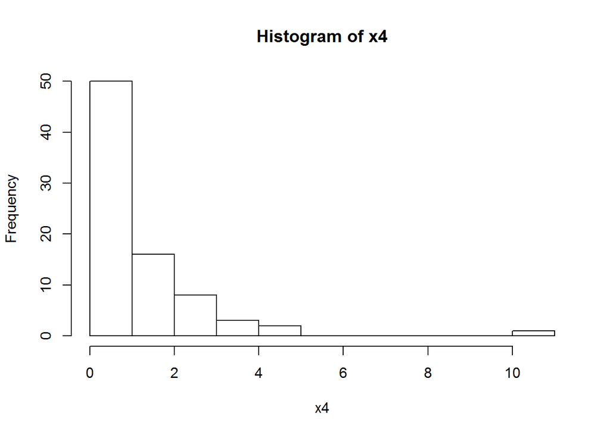

```r
hist(x4)
```

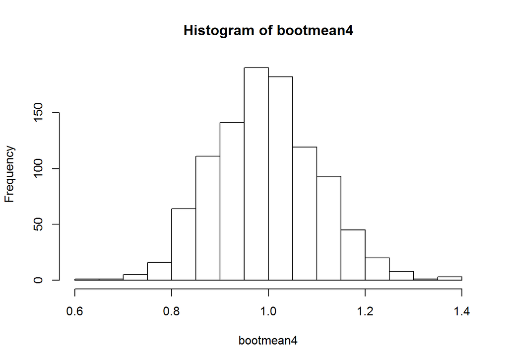

```r
hist (bootmean4)
```